# Uninsured Rates in Two Florida Counties (2008-2022)

Academic portfolio project

## Project objective

Explore annual uninsured percentages in Miami-Dade and Bradford counties, assess stationarity, fit candidate ARIMA models, and generate five-year forecasts. This cleaned portfolio version is based on the author’s original R code and report; it is **not** a claim that all original numerical findings have been reproduced.

## Data and preparation

The included CSV has 2008-2021 observations from the author’s cleaned Excel workbook and 2022 observations transcribed from the author’s updated report appendix. `PCTUI` is the uninsured **percentage**, not the number of uninsured people. `PCTUI_MOE` is the reported margin of error; this script does not use it as a modeling weight.

```r
library(forecast)
library(tseries)
library(ggplot2)
knitr::opts_chunk$set(echo=TRUE, fig.width=8, fig.height=4.5)
```

```r
# Knit this file from the repository root, or set the knit root to the repository root.
path <- if (file.exists("data/florida_uninsured_2008_2022.csv")) {
  "data/florida_uninsured_2008_2022.csv"
} else {
  "../data/florida_uninsured_2008_2022.csv"
}
dat <- read.csv(path, stringsAsFactors=FALSE)
stopifnot(all(c("Year", "County", "PCTUI") %in% names(dat)))
stopifnot(!anyDuplicated(dat[c("Year", "County")]))
stopifnot(all(is.finite(dat$PCTUI)), all(dat$PCTUI >= 0 & dat$PCTUI <= 100))
stopifnot(all(sort(unique(dat$Year)) == 2008:2022))
print(aggregate(PCTUI ~ County, data=dat, FUN=function(x) c(first=x[1], last=x[length(x)])))
```

```
##              County PCTUI.first PCTUI.last
## 1   Bradford County        24.6       14.4
## 2 Miami-Dade County        32.1       20.5
```

## Historical trends

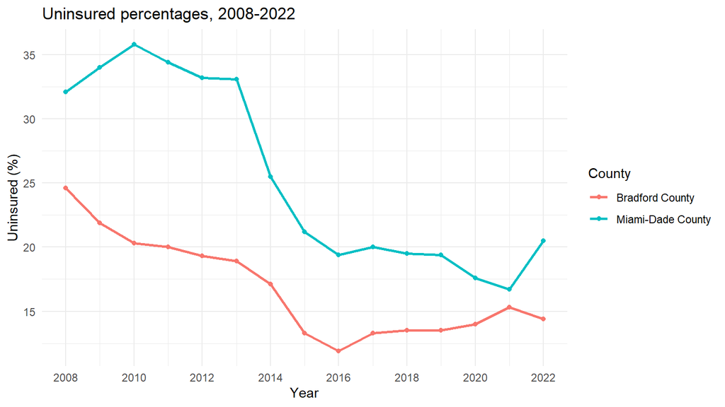

```r
ggplot(dat, aes(x=Year,y=PCTUI,color=County)) +
  geom_line(linewidth=1) + geom_point() +
  scale_x_continuous(breaks=seq(2008,2022,2)) +
  labs(title="Uninsured percentages, 2008-2022",y="Uninsured (%)",x="Year") +
  theme_minimal()
```

## Stationarity and ARIMA modeling

Annual observations provide only 15 points per county. Models and ADF tests should therefore be interpreted cautiously. `auto.arima` is run with `seasonal=FALSE` because these are annual observations, not a seasonal series.

```r
counties <- c("Miami-Dade County", "Bradford County")
series <- lapply(counties, function(nm) {
  d <- dat[dat$County == nm, ]
  d <- d[order(d$Year), ]
  stopifnot(identical(d$Year, 2008:2022))
  ts(d$PCTUI, start=2008, frequency=1)
})
names(series) <- counties
fits <- lapply(series, function(x) auto.arima(x, seasonal=FALSE, stepwise=FALSE, approximation=FALSE))
for (nm in counties) {
  cat("\n###", nm, "\n")
  print(adf.test(series[[nm]]))
  print(fits[[nm]])
  print(checkresiduals(fits[[nm]]))
}
```

```
##
## ### Miami-Dade County
##
##  Augmented Dickey-Fuller Test
##
## data:  series[[nm]]
## Dickey-Fuller = -0.83761, Lag order = 2, p-value = 0.9445
## alternative hypothesis: stationary
##
## Series: x
## ARIMA(0,1,0)
##
## sigma^2 = 7.776:  log likelihood = -34.22
## AIC=70.44   AICc=70.78   BIC=71.08
```

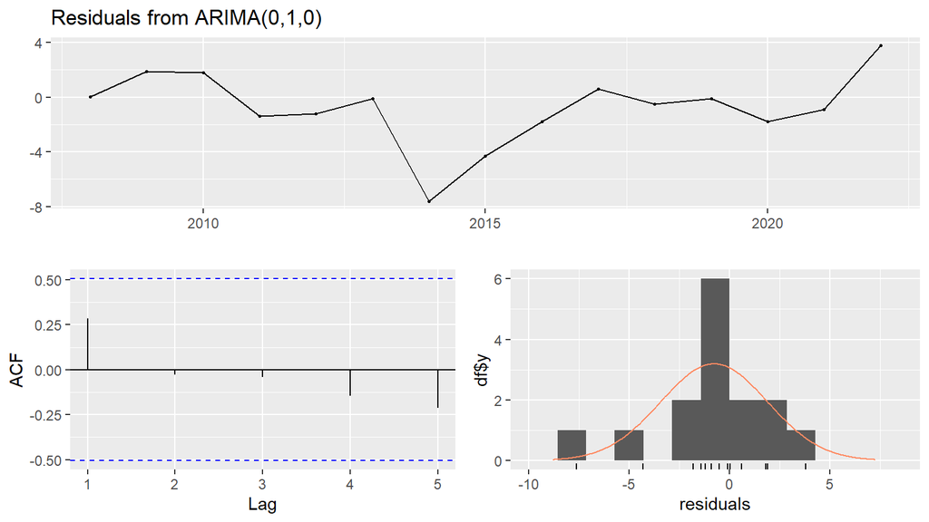

```
##
##  Ljung-Box test
##
## data:  Residuals from ARIMA(0,1,0)
## Q* = 1.5364, df = 3, p-value = 0.6739
##
## Model df: 0.   Total lags used: 3
##
##
##  Ljung-Box test
##
## data:  Residuals from ARIMA(0,1,0)
## Q* = 1.5364, df = 3, p-value = 0.6739
##
##
## ### Bradford County
##
##  Augmented Dickey-Fuller Test
##
## data:  series[[nm]]
## Dickey-Fuller = -0.72968, Lag order = 2, p-value = 0.9559
## alternative hypothesis: stationary
##
## Series: x
## ARIMA(0,1,1)
##
## Coefficients:
##          ma1
##       0.7918
## s.e.  0.2193
##
## sigma^2 = 1.588:  log likelihood = -23.08
## AIC=50.15   AICc=51.24   BIC=51.43
```

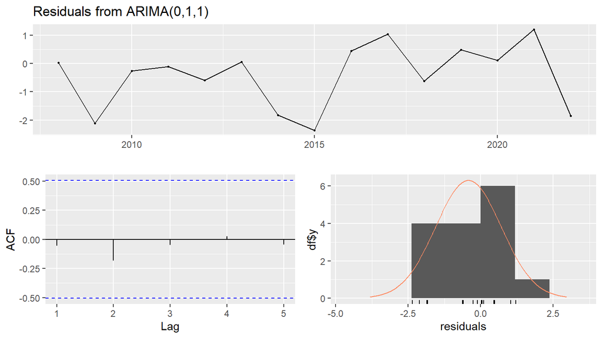

```
##
##  Ljung-Box test
##
## data:  Residuals from ARIMA(0,1,1)
## Q* = 0.77773, df = 3, p-value = 0.8548
##
## Model df: 1.   Total lags used: 4
##
##
##  Ljung-Box test
##
## data:  Residuals from ARIMA(0,1,1)
## Q* = 0.77773, df = 3, p-value = 0.8548
```

## Five-year forecasts

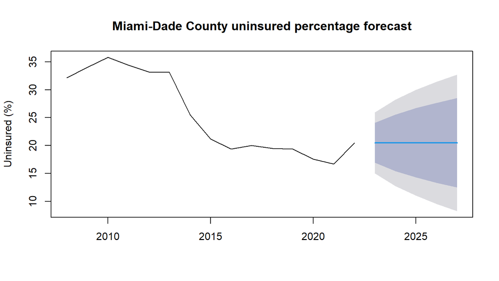

```
##      Point Forecast    Lo 80    Hi 80     Lo 95    Hi 95
## 2023           20.5 16.92638 24.07362 15.034621 25.96538
## 2024           20.5 15.44614 25.55386 12.770787 28.22921
## 2025           20.5 14.31031 26.68969 11.033686 29.96631
## 2026           20.5 13.35276 27.64724  9.569242 31.43076
## 2027           20.5 12.50914 28.49086  8.279041 32.72096
```

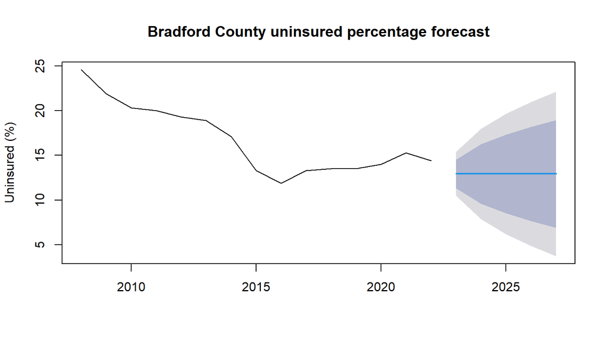

```
##      Point Forecast     Lo 80    Hi 80     Lo 95    Hi 95
## 2023       12.92927 11.314159 14.54438 10.459172 15.39937
## 2024       12.92927  9.615544 16.24300  7.861363 17.99718
## 2025       12.92927  8.530067 17.32847  6.201270 19.65727
## 2026       12.92927  7.663799 18.19474  4.876427 20.98211
## 2027       12.92927  6.921160 18.93738  3.740658 22.11788
```

```r
forecasts <- lapply(fits, forecast, h=5)
for (nm in counties) {
  plot(forecasts[[nm]], main=paste(nm, "uninsured percentage forecast"), ylab="Uninsured (%)")
  print(forecasts[[nm]])
}
```

## Cross-correlation (exploratory)

The original project explored correlations at different lags. Raw trends can create misleading cross-correlations, and the sign of a CCF lag must be checked before claiming one county leads the other. The plot below is exploratory, **not evidence of causation**.

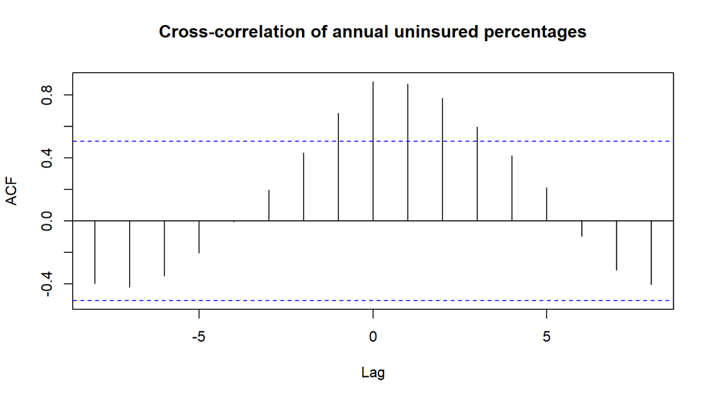

```r
ccf(series[["Miami-Dade County"]], series[["Bradford County"]],
    main="Cross-correlation of annual uninsured percentages")
```

## Interpretation

The source report describes a substantial decline in uninsured percentages over 2008-2022 in both counties, with different year-to-year patterns. Re-run the R Markdown document to obtain the selected models, diagnostics, and current forecast tables. Do not substitute the source report’s original model claims for the rerun output without verification.

## Limitations

- Only 15 annual observations per county; forecasts are uncertain.
- 2022 data came from the report appendix, not an independently re-imported 2022 Census CSV.
- The report’s 2022 standard-error column appears inconsistent with earlier years; those values were not carried into this dataset.
- Annual observations do not justify seasonal ARIMA parameters.
- County-level associations are not causal effects.